# Contact Topology

## 7.1 Transverse Knots

The **self-linking number** $\mathrm{sl}(T, S)$ of a transverse knot rel a Seifert surface $S$ is $\operatorname{lk}(T, T')$ for $T'$ a pushoff of $T$ determined by a trivialization of ${ \left.{{\xi}} \right|_{{S}} }$.

In this case, $\xi$ restricts to an ${\mathbb{R}}^2$ bundle over $\Sigma$, which is trivial since $\Sigma$ is closed with boundary and $e(\xi) \in H^2(S) = 0$. To see this, use $H^2(S) \cong H_0(S, {{\partial}}S) = 0$ by Lefschetz duality. This yields a section of the frame bundle over $S$, which gives a pushoff direction along the first basis vector:

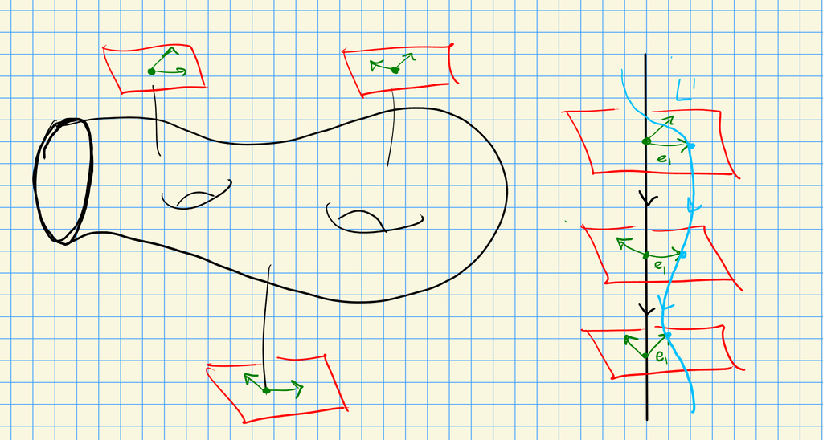

This turns out to be well-defined: it’s independent of the surface $S$ chosen and the trivialization of $\xi$. The difference of two trivializations gives a map $\pi_1(S) \to {\mathbb{Z}}$, which factors through $\pi_1(S)^{\operatorname{ab}}= H_1(S)$. The difference in surfaces is measured by ${\left\langle {e(S)},~{ \Sigma_1 {\textstyle\coprod}_T \Sigma_2 } \right\rangle}$, which is a glued surface.

# 8 Thursday, February 03

Last time: self-linking of transverse knots. Today: surfaces with transverse boundary. Let $\Sigma$ be a surface embedded in $(Y, \xi)$ with ${{\partial}}\Sigma$ transverse to $\xi$. Let $F$ be the characteristic foliation, the singular foliation on $\Sigma$ induced by ${ \left.{{\xi}} \right|_{{\Sigma}} }$. Equivalently, if $\xi = \ker \alpha$, consider the 1-form ${ \left.{{\alpha}} \right|_{{\Sigma}} }$. Generically, ${ \left.{{\ker \alpha}} \right|_{{{\mathbf{T}}\Sigma}} }$ is 1-dimensional except at finitely many points where $\alpha_p = 0$, i.e. $\xi$ is tangent to $\Sigma$. This line field integrates to a singular foliation. Recall that $\mathrm{sl}(L)$ is the self-linking number.

Take $\alpha = \,dz+x\,dy- y\,dx$ and $\Sigma = S^2$, then the singular foliation is given by

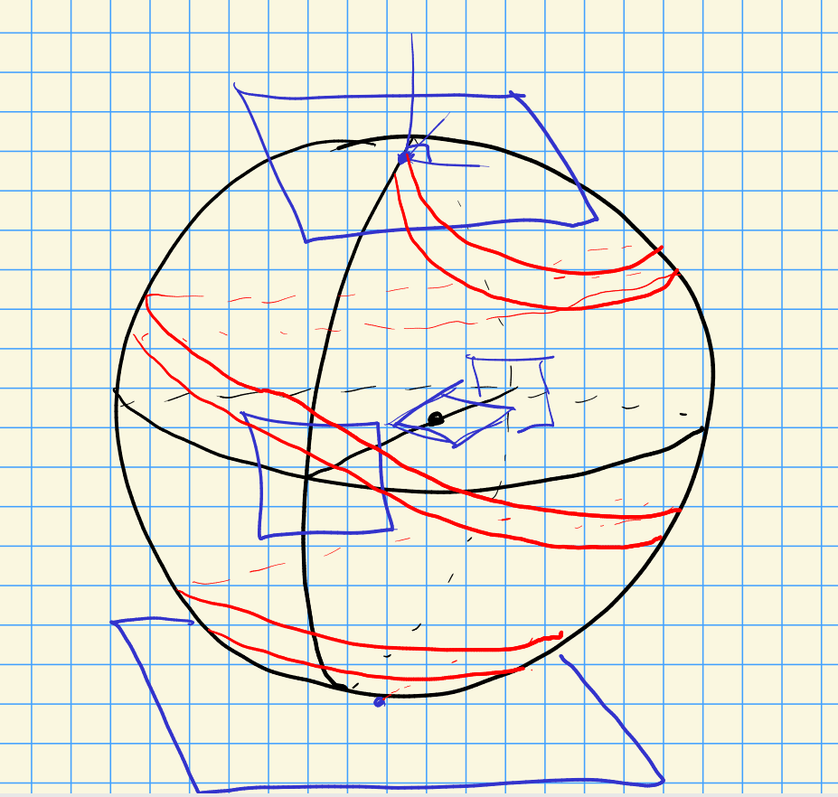

Two possible types of singularities, the local models:

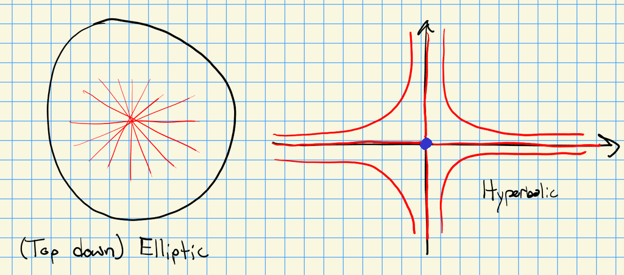

There are also two numerical invariants:

- $e_{\pm}$: the number of positive (resp. negative) elliptics
- $h_{\pm}$: the number of positive (resp. negative) hyperbolics

A theorem
$$\begin{align*}
{\left\langle {c(\Sigma)},~{ \Sigma} \right\rangle} = (e_+ - h_+) - (e_- - h_-)
.\end{align*}
If \(\Sigma\) is transverse, \(\mathrm{sl}({{\partial}}\Sigma, \Sigma) = -(e_+ - h_+) + (e_- - h_-)\).$$

## 8.1 Local Model 1: Elliptic

$\sigma$ is the $x,y{\hbox{-}}$plane and $\xi = \ker (\,dz+ x\,dy- y\,dx)$ with ${ \left.{{\alpha }} \right|_{{\Sigma }} }= x\,dy- y\,dx$. Set $V: x{\partial}_x + y{\partial}_y$ and $L' = \left\langle{x{\partial}_y - y{\partial}_x}\right\rangle$, and $\alpha(i) = x^2+y^2 = 1 > 0$.

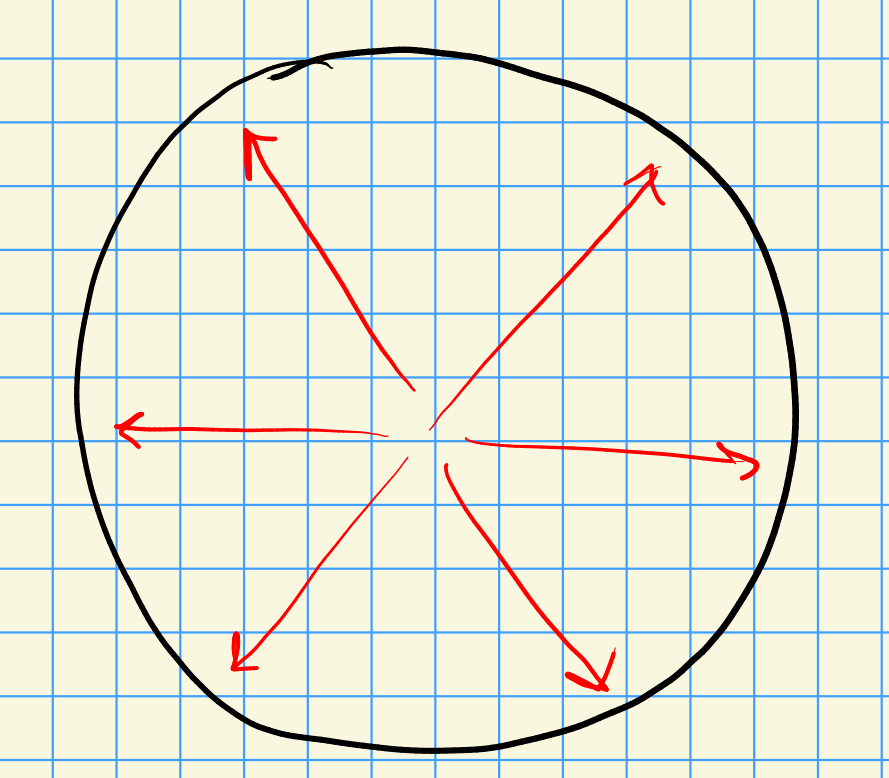

- Trivialize ${ \left.{{\xi}} \right|_{{\Sigma}} }$ to get $\tau = \left\langle{e_1, e_2}\right\rangle$ a fiberwise basis for $\xi$.
- Let $\tilde L$ be a pushoff in the $e_1$ direction.
- Compute $\mathrm{sl} = \operatorname{lk}(L, \tilde L)$.

Set

- $e_1 = {\partial}_x + y{\partial}_z$
- $e_2 = {\partial}_y - x{\partial}_z$
- $\rho = x {\partial}_x + y{\partial}_y$
- $\theta = x{\partial}_y - y{\partial}_x$.

Then
$$\begin{align*}
x\rho - y\theta = x(x{\partial}_x + y{\partial}_y) - y(-y {\partial}_x + x{\partial}_y) = (x^2+y^2)\,dx
.\end{align*}$$

Then

- $c_1 = x\rho - y\theta + y{\partial}_z$
- $\mkern 1.5mu\overline{\mkern-1.5muc_1\mkern-1.5mu}\mkern 1.5mu = x\rho + y{\partial}_z = \cos(\rho) + \sin(\theta) {\partial}_z$.

Example:

- $\theta = 0\implies e_1 = \rho$
- $\theta = \pi/4 \implies e_1 = {\sqrt 2\over 2}(\rho + {\partial}_z)$
- $\theta = \pi/2 \implies e_1 = {\partial}_z$

So here $\operatorname{lk}(U, \tilde U) = -1$:

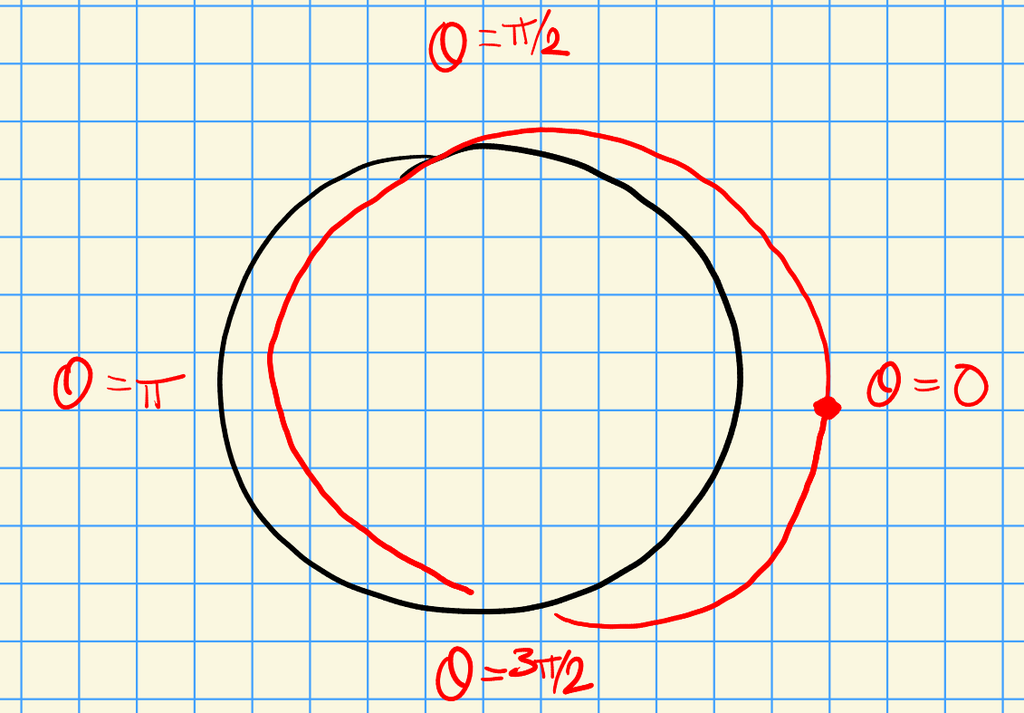

## 8.2 Local Model 2: Hyperbolic

Here $\xi$ is the $x,y{\hbox{-}}$plane, so $\xi = \ker (\,dz+ 2x\,dy+ y\,dx)$ with ${ \left.{{\alpha}} \right|_{{\Sigma}} } = 2x\,dy+ y\,dx$ and $V = y{\partial}_y + dx{\partial}_x\in \ker({ \left.{{\alpha }} \right|_{{\Sigma}} })$.

The Euler class of a real vector bundle $E \xrightarrow{\pi} X$ is the obstruction to finding a nonvanishing section $s$ of $E$, given by $e(E) \in H^k(X)$. It is Poincare dual to $[s^{-1}(0)] \in H_{n-k}(X, {{\partial}}X)$. For the tangent bundle, $e({\mathbf{T}}X)\in H^{n}(X)$, and
$$\begin{align*}
{\left\langle {e({{\mathbf{T}}X} )},~{[X]} \right\rangle} = \chi(X)
.\end{align*}
Since a section of \({\mathbf{T}}X\) is a vector field, \(e({\mathbf{T}}X)\) is an obstruction to finding a nonvanishing vector field. If \({{\partial}}X \neq \emptyset\) and \(t\) is a section of \({ \left.{{E}} \right|_{{{{\partial}}X}} }\), there is a relative Euler class \(e(E, t)\in H^k(X, {{\partial}}X) \cong H_{n-k}(X)\). Similarly,
\begin{align*}
{\left\langle {e({\mathbf{T}}X, t)},~{[X]} \right\rangle} = \chi(X)
.\end{align*}$$

Note $\chi({\mathbb{D}}) = 1$, so any vector field has a singularity?

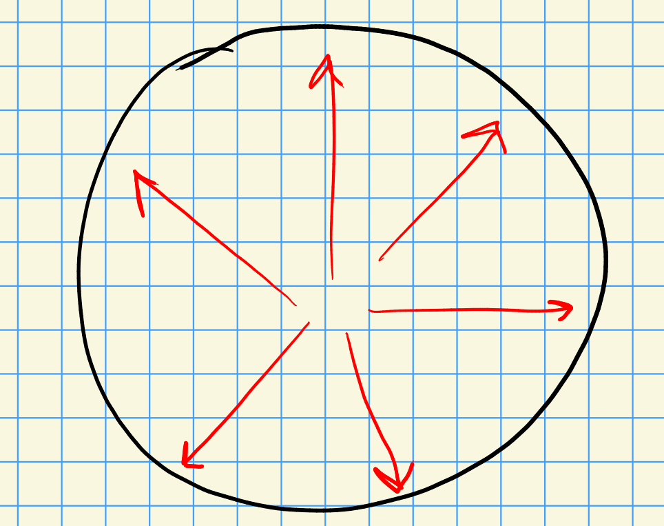

The total class is the sum of the relative obstructions. If $\sigma = \Sigma_1 { \displaystyle\coprod_{{{\partial}}} } \Sigma_2$ and $\tau$ is a nonvanishing section of ${ \left.{{\Sigma}} \right|_{{{{\partial}}\Sigma_1}} } = { \left.{{\Sigma}} \right|_{{{{\partial}}\Sigma_2}} }$, then
$$\begin{align*}
c(E) = e({ \left.{{E}} \right|_{{\Sigma_1}} }, \tau) + c({ \left.{{E}} \right|_{{\Sigma_2}} }, \tau)
.\end{align*}$$

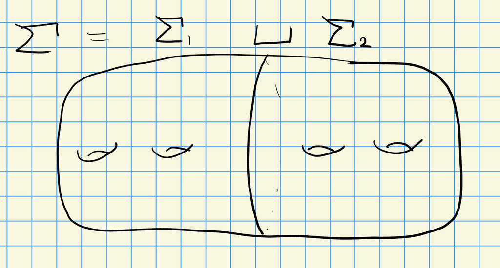

## 8.3 More Contact Geometry

Let $\Sigma$ have transverse boundary with characteristic foliation $F$, and let $V$ be the vector field directing $F$, so $V \in \xi \cap{\mathbf{T}}\Sigma$. We can assume $V$ is outward-pointing along ${{\partial}}\Sigma$.

Check that

- $\chi(\Sigma) = e({\mathbf{T}}\Sigma, V) \in H^2(\Sigma, {{\partial}}\Sigma) \cong H_0(\Sigma)$
- $\mathrm{sl}({{\partial}}\Sigma, \Sigma) = e(\xi, V) \in H^2(\Sigma, {{\partial}}\Sigma)$
- $e_+ + e_-$ correspond to $+1$ in $e({\mathbf{T}}\Sigma, V)$,
- $h_+, h_-$ correspond to $-1$ in $e({\mathbf{T}}\Sigma, V)$.

Proof: near a zero, $V$ determines a map $S^1\to S^1$ and the contribution to $e$ is the degree of this map.

- $e_+$ contributes $-1$ to $e(\xi, V)$, by the same computation of $\mathrm{sl}(U)$ for $U$ the unknot.
- $e_-$ contributes $-(-1) = +1$ to $e(\xi, V)$.
- $h_+$ contributes $+1$ to $e(\xi, V)$
- $h_-$ contributes $-(+1) = -1$ to $e(\xi, V)$.

Proof: exercise.

Bennequin inequality:
$$\begin{align*}
\mathrm{sl}(T, \Sigma) \leq -\chi(\Sigma) \implies e_+ + h_+ + e_- + h_- \leq -(e_+ + e_- - h_+ - h_-) \iff e_- \leq h_-
.\end{align*}
Try to cancel in pairs:$$

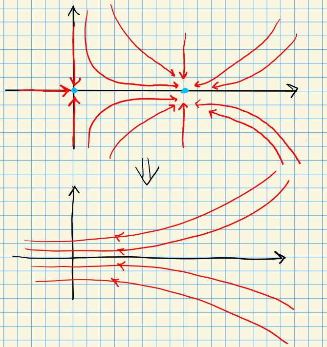

The inequality follows if we can cancel every $e_-$ with some $h_-$.

# 9 Tuesday, February 08

Topics for talks:

- Thom-Pontryagin
- Brieskorn spheres
- Milnor fibrations
- Lens spaces

Every closed oriented 3-manifold $Y$ admits a (positive) contact form.

Three proofs:

- Lickorish-Wallace, using that $Y$ is Dehn surgery on a link in $S^3$,
- Birman-Hildon, using that $Y$ is a branched cover of $S^3$,
- Alexander, using that $Y$ admits an open book decomposition.

Dehn surgery for slope $p/q$: for $K \hookrightarrow S^3$, cut out $\nu(K) \cong S^1\times {\mathbb{D}}$ and re-glue by a map ${{\partial}}(S^1\times {\mathbb{D}}) \to {{\partial}}\nu(K)$ such that $[\left\{{0}\right\} \times {{\partial}}{\mathbb{D}}] = p[m] + q[\ell] \in H^1({{\partial}}\nu (K) )$. Use that $\nu(K) \cong S^1\times {\mathbb{D}}$ and ${{\partial}}\nu(K) \cong S^1\times S^1 = T^2$. Idea: wrapped $p$ times longitudinally, $q$ times around the meridian.

Recall:

- Every knot $K$ can be $C^0$ approximated by a transverse knot
- Every link $L$ can be $C^0$ approximated by a transverse link
- Neighborhood theorem: for every transverse knot $K$, there is a $w(K)$ and a contactomorphism to a standard model: $S^1\times {\mathbb{D}}$ in coordinates $(\phi, r, \theta)$ with $0\leq r\leq \delta$ and $\alpha = d\phi + r^2\,d\theta$. Re-gluing corresponds to the map ${\left[ {0, \delta, \theta} \right]}\mapsto {\left[ {q\theta, \delta, p\theta} \right]}$.

$$\begin{align*}
{\left[ {0, \delta, \mkern 1.5mu\overline{\mkern-1.5mu\theta\mkern-1.5mu}\mkern 1.5mu} \right]} &\mapsto {\left[ {q\mkern 1.5mu\overline{\mkern-1.5mu\theta\mkern-1.5mu}\mkern 1.5mu, \delta, p\mkern 1.5mu\overline{\mkern-1.5mu\theta\mkern-1.5mu}\mkern 1.5mu} \right]} \\
{\left[ {\mkern 1.5mu\overline{\mkern-1.5mu\pi\mkern-1.5mu}\mkern 1.5mu, \mkern 1.5mu\overline{\mkern-1.5mur\mkern-1.5mu}\mkern 1.5mu, \mkern 1.5mu\overline{\mkern-1.5mu\theta\mkern-1.5mu}\mkern 1.5mu} \right]} &\mapsto {\left[ {\phi,r,\theta} \right]}
.\end{align*}
If \(p, q\) are coprime there exist \(m,n\) with \(pm-qn = 1\). So define
\begin{align*}
\psi: {\left[ {\mkern 1.5mu\overline{\mkern-1.5mu\pi\mkern-1.5mu}\mkern 1.5mu, \mkern 1.5mu\overline{\mkern-1.5mur\mkern-1.5mu}\mkern 1.5mu, \mkern 1.5mu\overline{\mkern-1.5mu\theta\mkern-1.5mu}\mkern 1.5mu} \right]} &\mapsto {\left[ {\phi,r,\theta} \right]}
,\end{align*}
so
\begin{align*}
\psi^*(\alpha) = d(\alpha\mkern 1.5mu\overline{\mkern-1.5mu\theta \mkern-1.5mu}\mkern 1.5mu+ m\mkern 1.5mu\overline{\mkern-1.5mu\phi\mkern-1.5mu}\mkern 1.5mu) + r^2d(p\mkern 1.5mu\overline{\mkern-1.5mu\theta \mkern-1.5mu}\mkern 1.5mu+ n\mkern 1.5mu\overline{\mkern-1.5mu\phi\mkern-1.5mu}\mkern 1.5mu) = (q+r^2p)d\mkern 1.5mu\overline{\mkern-1.5mu\theta \mkern-1.5mu}\mkern 1.5mu+ (m+r^2n)d\mkern 1.5mu\overline{\mkern-1.5mu\phi\mkern-1.5mu}\mkern 1.5mu
.\end{align*}
We want \(\alpha = h_1(r) d\mkern 1.5mu\overline{\mkern-1.5mu\theta \mkern-1.5mu}\mkern 1.5mu+ h_2(r) d\mkern 1.5mu\overline{\mkern-1.5mu\theta\mkern-1.5mu}\mkern 1.5mu\) to be contact and satisfy \((h_1, h_2) = (r^2, 1)\) near \(r=0\) and \((q+r^2 p, m+r^2 n)\) near \(r=\delta\). This requires
\begin{align*}
d\alpha = h_1' \,dr\wedge d\mkern 1.5mu\overline{\mkern-1.5mu\phi \mkern-1.5mu}\mkern 1.5mu+ h_2' \,dr\wedge d\mkern 1.5mu\overline{\mkern-1.5mu\theta \mkern-1.5mu}\mkern 1.5mu= (h_2 h_1' - h_1 h_2') dr \wedge d\mkern 1.5mu\overline{\mkern-1.5mu\theta \mkern-1.5mu}\mkern 1.5mu\wedge d\mkern 1.5mu\overline{\mkern-1.5mu\phi\mkern-1.5mu}\mkern 1.5mu
,\end{align*}
which happens iff
\begin{align*}
\operatorname{det}
\begin{bmatrix}
h_2 & h_2'
\\
h_1 & h_1'
\end{bmatrix}
> 0
.\end{align*}$$

Think of ${\left[ {h_2, h_1} \right]}$ as a path with tangent vector ${\left[ {h_2', h_1'} \right]}$. This requires moving counterclockwise.

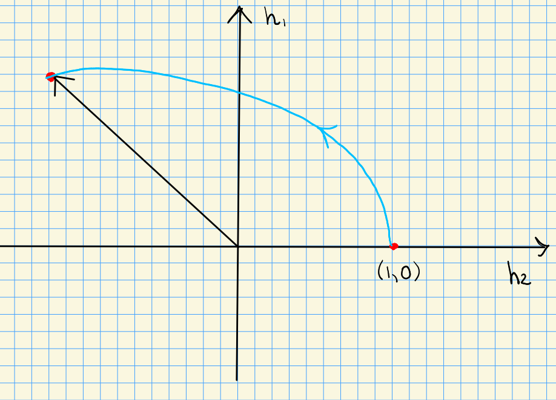

An **open book decomposition** of $Y$ is a pair $(B, \pi)$ where

- $B$ is a link in $Y$, called the **binding**
- $\pi: Y\setminus B\to S^1$ is a locally trivial fibration of relatively compact fibers **pages**

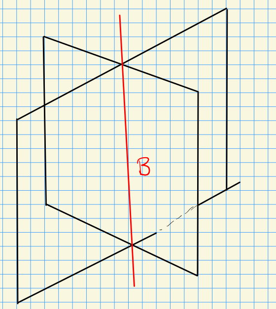

An open book decomposition is determined by its monodromy map $\phi: \Sigma_0\to \Sigma_0$, which determines a class $[\phi] \in {\operatorname{MCG}}(\Sigma_0)$. Form
$$\begin{align*}
Y\setminus\nu(B) \cong {\Sigma \times I \over \phi(x) \times\left\{{0}\right\} \sim x\times\left\{{1}\right\}}
,\end{align*}
which is a glued cylinder:$$

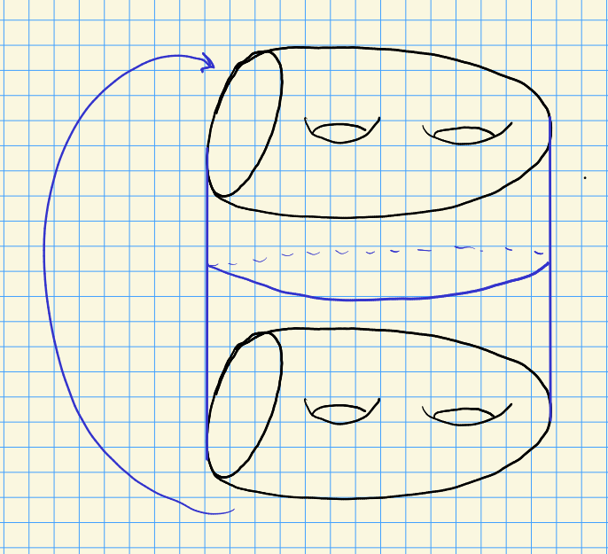

An open book decomposition **supports** a contact structure $\xi$ iff there exists a contact form $\alpha$ such that $d\alpha$ is an area form on each page and $B$ is a transverse link in $(B, \xi)$.

Every open book decomposition admits a contact structure.

Every $(Y^3, \xi)$ with $Y$ closed has a supporting open book decomposition.

If an open book decomposition supports $\xi_1$ and $\xi_2$, then $\xi_1$ is isotopic to $\xi_2$.

Two steps:

- Form a mapping cylinder of the monodromy map $\phi$,
- Extend over the binding, using the same idea as in Dehn surgery.

Choose an area form $\omega$ on $\Sigma$ and a primitive $\beta$ with $d\beta = \omega$. Let $\beta_1 \mathrel{\vcenter{:}}=\phi^*\beta$ and $\beta_0 = \beta$, then set
$$\begin{align*}
\beta_t = t\beta_1 + (1-t)\beta_0
.\end{align*}
This yields a 1-form on \(\Sigma\times I\) that extends to the mapping cylinder. Moreover \(d\beta_t = td\beta_1 + (1-t)d\beta_0\) is an area form on \(\sigma\times \left\{{t}\right\}\) and \(\alpha = \,dt+ {\varepsilon}\beta_t\) is a contact form for small \({\varepsilon}> 0\). Then \(d\alpha = {\varepsilon}d\beta_t + {\varepsilon}\,dt\wedge \dot{\beta}_t\) and \(\alpha \wedge d\alpha = {\varepsilon}dt \wedge d\beta_t + { \mathsf{O}} ({\varepsilon}^2)\).$$

# 10 Tuesday, February 15

Missed due to orthodontic appointment! Please send me notes. :)

# 11 Thursday, February 17

Let $\Sigma \subseteq (Y^3, \xi)$.

- Characteristic foliation: $F = \xi \cap{\mathbf{T}}\Sigma$, complicated but necessary
- Dividing set: a multicurve, simpler

If $\Sigma$ is convex with a dividing set $\Gamma$ and $F$ is any foliation divided by $\Gamma$, there is a $C^0{\hbox{-}}$small isotopy $\phi_t$ wt

- $\phi_0(\Sigma) = \Sigma, \phi_t(\Gamma) = \Gamma$
- $\phi_t(\Sigma)$ is convex for all $t \in [0, 1]$
- The characteristic foliation of $\phi_1(\Sigma)$ is $F$.

Idea: dividing sets give ways to detect overtwisted contact structures.

If $\Sigma = S^2$ and ${\sharp}\Gamma \geq 2$, then $(Y, \xi)$ is overtwisted. Recall that an overtwisted disc is an embedded $D^2$ with Legendrian boundary such that $\mathrm{tb}({{\partial}}D) = 0$ and $\mathrm{tw}(\xi, {{\partial}}D)$.

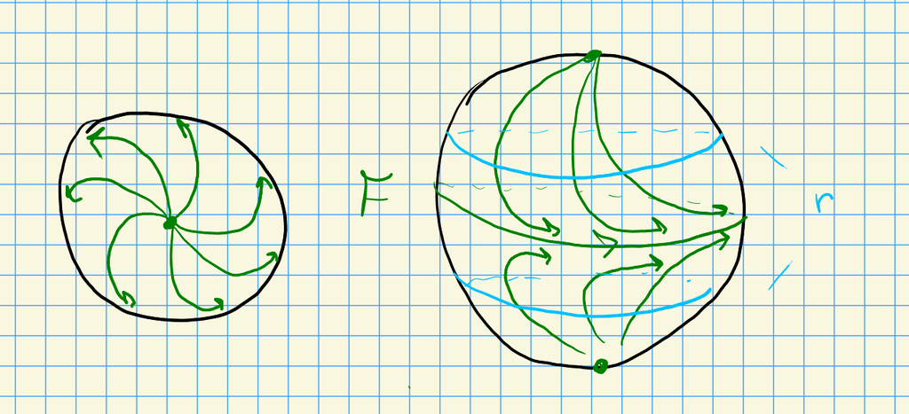

Generalize to an arbitrary number of components ${\sharp}\Gamma = n$.

Same if $\Sigma \neq S^2$ and $\Gamma$ contains a contractible curve. Contrapositively, if $(Y, \xi)$ is tight, then either

- $\Sigma = S^2$ and $\Gamma$ is connected, or
- $\Sigma \neq S^2$ and $\Gamma$ has no contractible components.

Consider tight contact structures on $S^3$. Choose Darboux $B^3$ neighborhoods at the ends, and note the interior is $S^2\times [0, 1]$:

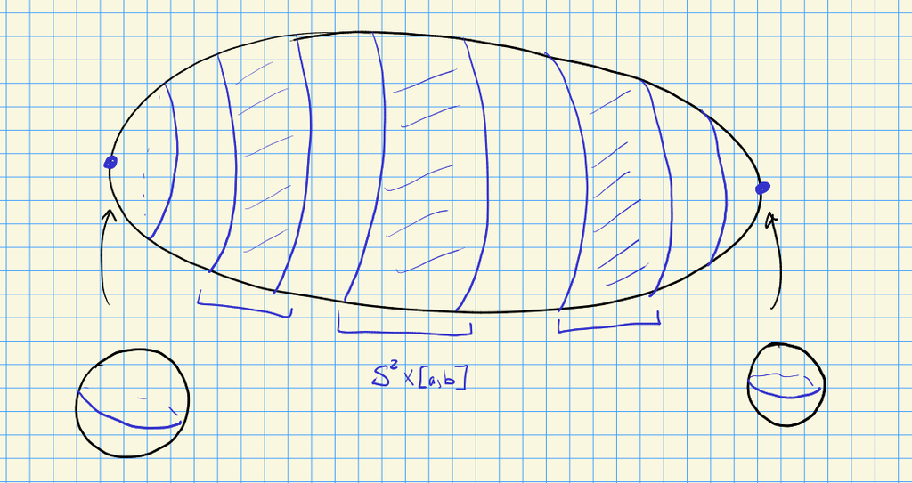

The $S^3\times \left\{{t_0}\right\}$ slices can be perturbed to be complex. So there is only one tight contact structure on $S^3$.

What can $F$ look like on an $S^2$ in a tight $(Y,\xi)$? $F$ can be perturbed to be Morse-Smale.

- There are a finite number of elliptic/hyperbolic singularities
- There are nondegenerate periodic orbits, either attracting or repelling
- There are no saddle-saddle arcs
- The limit sets are singularities or periodic orbits

Dimension 3: strange attractors! Two types of limit sets:

- $\omega$ limit sets: $x\in Y$ where there exists a sequence $\left\{{t_1 < \cdots }\right\}$ with $\phi(t_k)\to x$.
- $\alpha$ limit sets: $x\in Y$ where there exists a sequence $\left\{{t_1 > \cdots }\right\}$ with $\phi(t_k)\to x$.

For $S^2$, take $S^+$ with an outward pointing vector field.

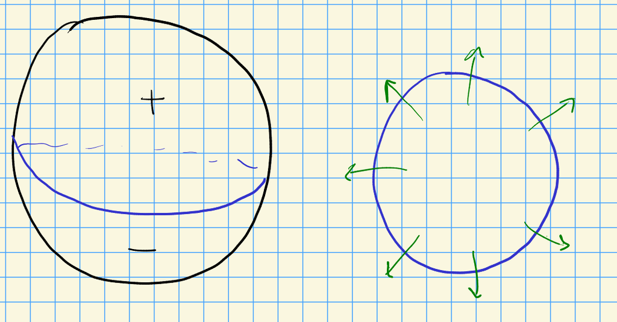

There are no periodic orbits since $(Y, \xi)$ is tight. The only limit sets are singular points. $\chi(D) = 1 = {\sharp}e - {\sharp}h$. Stable manifold of $h$: ${\operatorname{Stab}}_h$ are $x\in D^2$ such that there exists a flow like with $\phi(0) = x$ and $\phi(t) \to h$ Form a 1-complex $\displaystyle\bigcup_h { \operatorname{cl}} _X({\operatorname{Stab}}_h)$ – this contains no cycles, thus this is a tree, and the dividing set is a neighborhood of the tree.

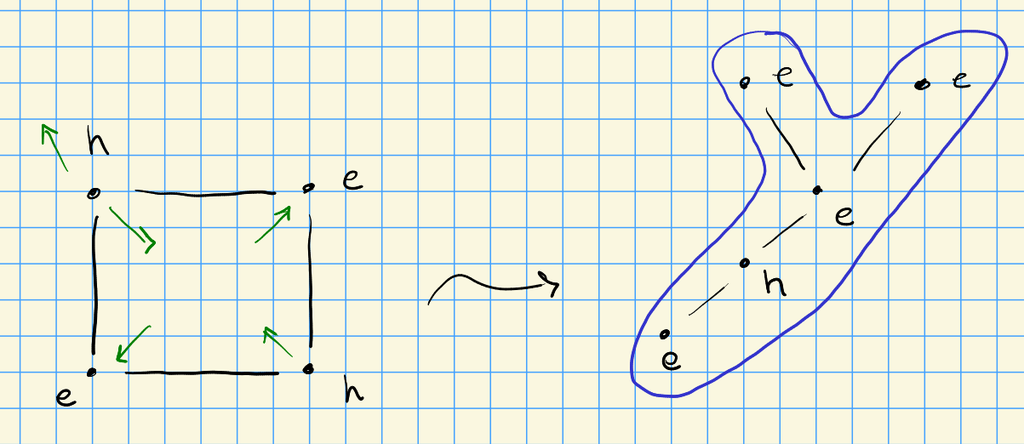

If $F$ on $\Sigma$ is Morse-Smale, then it admits dividing curves.

Let $G = \displaystyle\bigcup_h { \operatorname{cl}} ({\operatorname{Stab}}_h) \cup\displaystyle\bigcup_e e_t$ along with all of the repelling periodic orbits. Then $\Gamma = {{\partial}}\nu(G)$ divides $F$.

If $\Sigma$ is orientable, then there is a $C^\infty$ small perturbation of $F$ such that it is Morse-Smale.

Every oriented $\Sigma \subseteq (Y, \xi)$ can be perturbed to be convex.

Near $\Sigma$, $\alpha = \beta_t + \alpha_t \,dt$ and $\beta_0$ define $F$. By Peixoto there exists $\tilde \beta_t$ such that$\tilde \beta_t$ defines a Morse-Smale $F$. For ${\left\lVert {\beta - \tilde\beta} \right\rVert}_{C^\infty} \ll {\varepsilon}$, $\tilde \alpha = \tilde \beta_t + \alpha_t \,dt$ is contact. Then $\alpha_s = s\tilde\alpha + (1-s)\alpha$ is a path of contact forms, so by Gray stability there is an isotopy $\phi_s$ such that $\phi_s^*(\alpha_s) = \lambda_s \alpha$ and we can take $\phi_1(\Sigma)$ to be our surface.

If $(\Sigma, \tilde F)$ admits dividing curves, then it is convex.

# 12 Thursday, February 24

Last time: there is a unique tight contact structure on $S^3$, using the existence of a contact structure on $S^3\times I$. Next: tight contact structures on

- $T^2\times I$
- $S^1\times {\mathbb{D}}^2$
- $L(p, q)$
- $T^3$

Given dividing sets of $\Gamma_0, \Gamma_1 \in T^2\times I$, how can contact structures vary in a family. Tightness implies no contractible components in $\Gamma$, so $\Gamma$ consists of $2n$ embedded curves of slow $p/q$. So the dividing set is governed by two parameters.

The only change to the dividing set in a generic family can be:

- Retrograde saddle-saddle, yielding by pass moves.

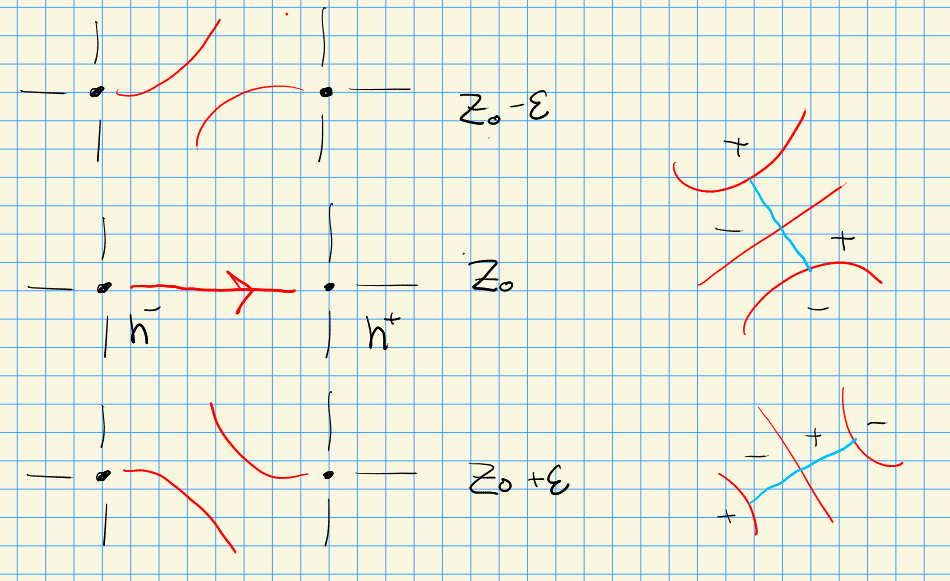

Given any contact structure on $\Sigma \times I$ with dividing sets $\Gamma_0, \Gamma_1$, $\xi$ is determined by a finite number of bypass moves.

Diagrams?

$\vdots$

Given $\Gamma_0$ with slope $p/q$ and $\Gamma_1$ with slope $r/s$, form a Farey graph:

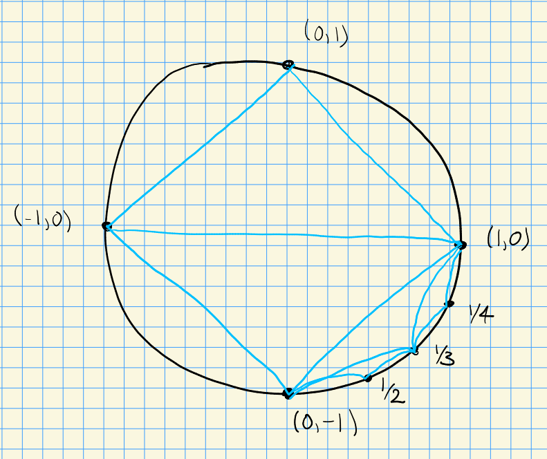

$\vdots$

If $L$ is a Legendrian knot in $M$, then a neighborhood of $L$ is contactomorphic to a neighborhood of a zero section in $J(S^1) \cong {\mathbb{R}}\times {\mathbf{T}} {}^{ \vee }S^1 \cong S^1\times {\mathbb{R}}^2$..

Write this in coordinates as $(z, (x, y))$, so $\alpha = \,dz-y\,dx$ with $x\in {\mathbb{R}}/{\mathbb{Z}}$. Then $v(L) = \left\{{y^2+z^2\leq {\varepsilon}}\right\}$, $y=r\cos\theta, z=r\sin\theta$. $T^2 = \left\{{x, \theta}\right\}, { \left.{{\alpha}} \right|_{{T^2}} } = y\,d\theta-y\,dx= {\varepsilon}\cos\theta (\,d\theta- \,dx)$. Unwrap:

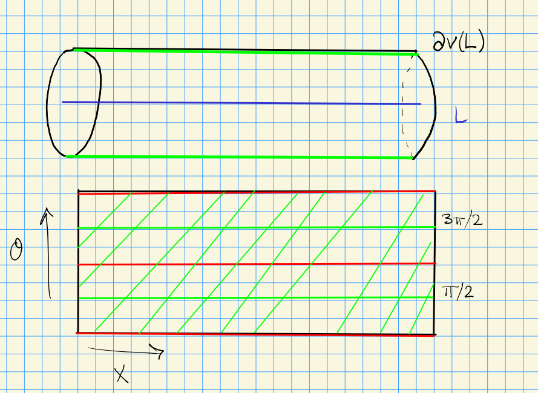

Note that $\,d\alpha> 0$ at $\pi/2$ and $\,d\alpha< 0$ at $3\pi/2$. Idea: given two unrelated surfaces with their own foliations, how do they interact at the boundary? Dividing sets on each can be extended into the annulus, and this reduces to a combinatorial problem of how to connected arcs:

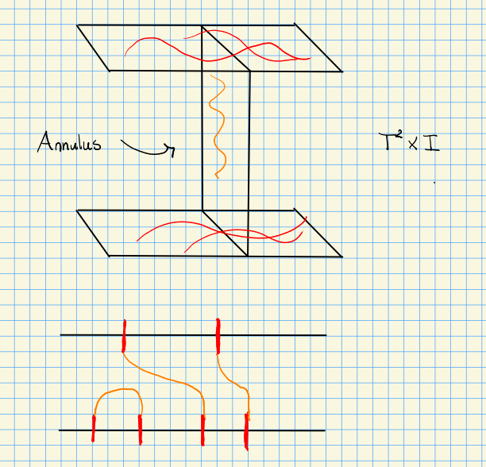

# 13 Tuesday, March 15

> See https://arxiv.org/pdf/math/9910127.pdf

Last time: classifying tight contact structures on $T^3$. Some contact structure:
$$\begin{align*}
\xi_n = \ker( \cos(2\pi n z) \,dx- \sin(2\pi n z)\,dy)
.\end{align*}
Realize \(T^3\) as a cube with faces glued, then moving in the \(z\) direction twists \(n\) times as you traverse the cube. We can reduce this to \(\xi_1\) using \({\left[ {x,y,z} \right]}\mapsto {\left[ {x,y,nz} \right]}\).$$

Goal: classify tight contact structures on lens spaces $L_{p, q} = T^2\times I/\sim$. We can discretize the contact structure on $\Sigma\times I$ into a finite number of *bypass moves* on the dividing sets. The basic move:

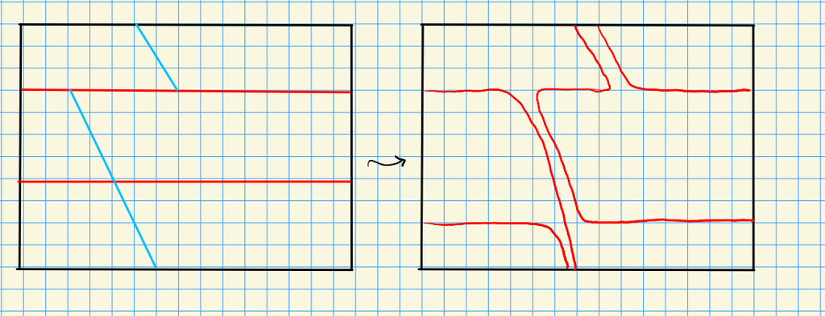

A **basic slice** is a contact structure on $T^2$ such that

- $T^2\times\left\{{0}\right\}$ is convex with 2 dividing curves of slope 0
- $T^2\times\left\{{1}\right\}$ is convex with 2 dividing curves of slope -1
- $\xi$ is tight
- $\xi$ is minimally twisting, so if $T^2 \subseteq T^2\times I$ is convex then ${\mathrm{slope}}(r) \in [-1, 0]$.

There are exactly 2 basic slices. Both embed in $(T^3, \xi_1) = \ker(\cos(2\pi z)\,dx- \sin(2\pi z)\,dy) = T^2\times I/\sim$, and are given by

- $(T_2\times [0, 1/8], \xi_1)$
- $(T_2\times [1/2, 5/8], \xi_1)$

Step 1: There are at most 2 basic slices. Reduce to $S^1\times D^2$ by removing a convex annulus. Note that $T^2\times I\setminus(S^1\times I) \cong S^1\times I^2 \cong S^1\times D^2$.

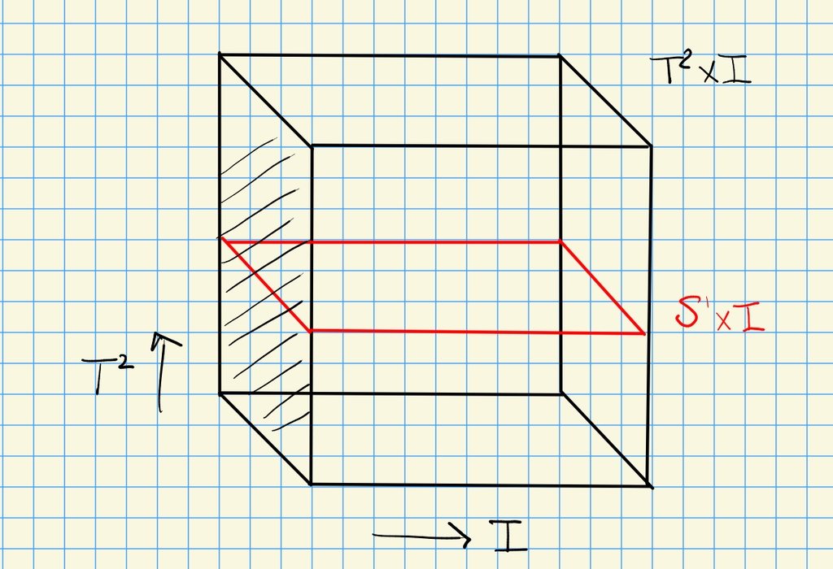

Since the boundary is convex, we can make the foliations on both of the ruling curves of slope $\infty$.

> ?

Take an annulus $A$ with some condition on ${{\partial}}A$, perturb to be convex? Something contradicts the “minimally twisting” assumption, involving these pics:

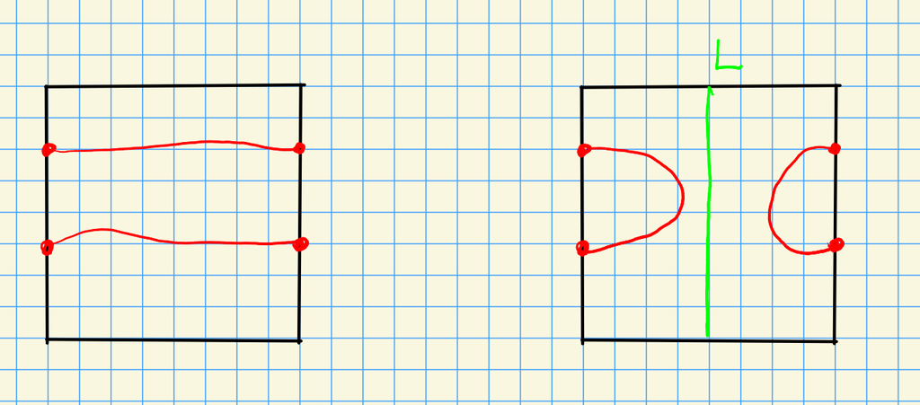

Smooth corners?

> ?

Let $(M,\xi)$ be a contact 3-manifold with ${ \left.{{\xi}} \right|_{{{{\partial}}M}} }$ trivial. Let $s$ be a nonvanishing section of ${ \left.{{\xi}} \right|_{{{{\partial}}M}} }$, then the **relative Euler class** $e(\xi, s) \in H^2(M, {{\partial}}M;{\mathbb{Z}}) \cong H_1(M)$ (by Lefschetz duality) is the dual of the vanishing set of an extension of $s$ to a section of $\xi$ on $M$.

In this case $\dim s^{-1}= \dim M - \dim \xi$.

If $\Sigma \hookrightarrow(M,\xi)$ is a properly embedded convex surface and $s$ is a section of ${ \left.{{\xi}} \right|_{{{{\partial}}M}} }$ that is tangent to ${{\partial}}\Sigma$ with the correct orientation, then
$$\begin{align*}
{\left\langle {e(\xi, s)},~{\Sigma} \right\rangle} = \chi(\Sigma_+) - \chi(\Sigma_-)
.\end{align*}
where \({\left\langle {{-}},~{{-}} \right\rangle}: H^2(M, {{\partial}}M;{\mathbb{Z}}) \times H_2(M, {{\partial}}M; {\mathbb{Z}}) \to {\mathbb{Z}}\).$$

Note $H_2(T^2\times I, {{\partial}}; {\mathbb{Z}}) = \left\langle{[\alpha\times I], [\beta\times I]}\right\rangle$ where $H_2(T^2) = \left\langle{\alpha, \beta}\right\rangle$.

# 14 Tuesday, March 22

## 14.1 Farey Graphs

Build a graph on the hyperbolic plane in the Poincare disc model:

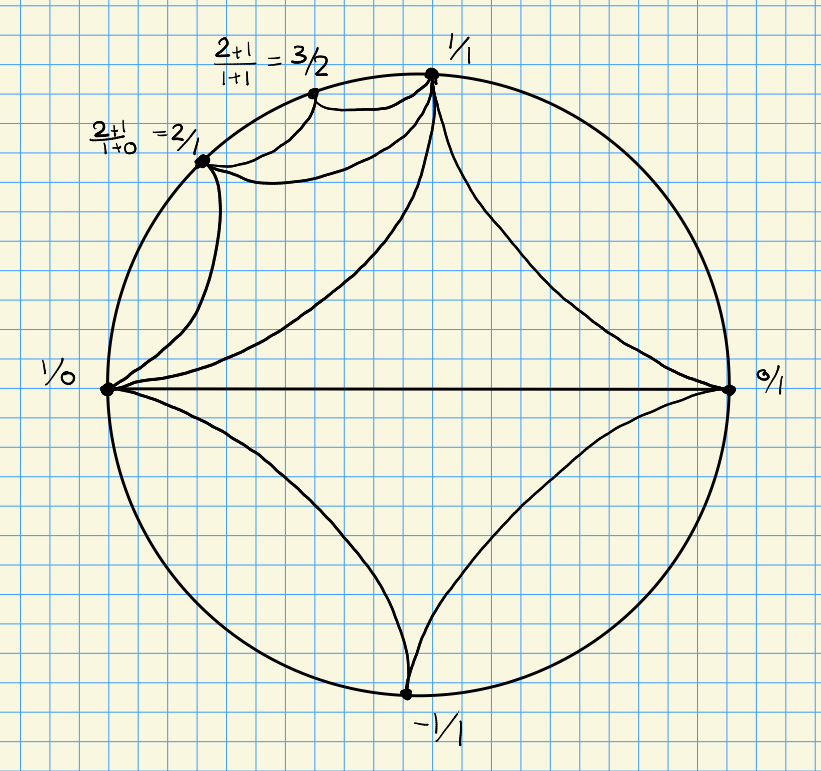

Here every midpoint corresponds to adding numerators and denominators respectively.

Associate slopes:

- $0/1 \leadsto 1\alpha + 0 \beta$
- $1/0 \leadsto 0\alpha + 1 \beta$
- $1/1 \leadsto 1\alpha + 1 \beta$

Any pair of these is a ${\mathbb{Z}}{\hbox{-}}$basis for $H^1(T^2; {\mathbb{Z}})\cong {\mathbb{Z}}{ {}^{ \scriptscriptstyle\times^{2} } }$. Use ${\operatorname{SL}}_2({\mathbb{Z}}) \hookrightarrow{\operatorname{PSL}}_2({\mathbb{C}})$ to realize any change of basis as an isometry of ${\mathfrak{h}}$. This makes the interior/exterior of any tile isometric to the full upper/lower half-disc.

Basic moves: bypasses

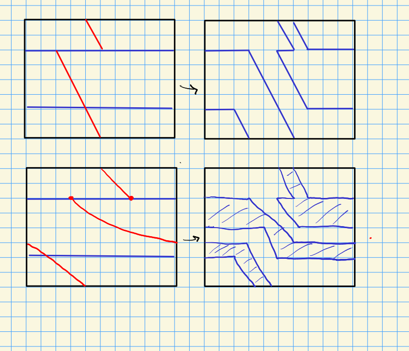

The first case corresponds to slopes $r\in (-\infty , -1)$ and the second to $r\in (-1, -1/2)$. Idea: the resulting dividing set is locally constant in perturbations of $r$, provided one doesn’t cross the endpoints of the curve for the bypass move. This produces a continued fraction defined inductively by $r_0 = {\left\lfloor -{p\over q} \right\rfloor}$, writing $-{p\over q} = r_0 -{1\over {p'/q'}} = - {q'\over p'}$ with $-p/q < -p'/q' < -1$ and thus $0 < -{p\over q} - r_0 < 1$, so set $r_1 = {\left\lfloor -{p'\over q'} \right\rfloor}$. This yields
$$\begin{align*}
-{p\over q} = r_0 - {1\over r_1 - {1\over r_2 - \cdots}} = [r_0, r_1,\cdots, r_m]
,\end{align*}
which terminates in finitely many steps since \(p/q\) is rational. Note that \(r_i \leq -1 \implies {\left\lfloor r_i \right\rfloor}\leq -2\).$$

If $r=-p/q = [r_0, \cdots, r_k]$ in a continued fraction expansion and $s=a/b$ is the first point connected to $p/q$ while moving counterclockwise from $0/1$ on the Farey graph, then $-a/b = [r_0, \cdots, r_{k}+1]$.

This gives the minimal graph path from $p/q$ back to $0/1$ by jumping the maximal distance along the circle to $a/b$. Noting that $[r_1, \cdots, r_{k-1}, -1] = [r_1, \cdots, r_{k-1} + 1]$ which is a shorter continued fraction.

Let $p/q = 53/17$, then

- $r_0 = -4 = -68/17$
- $r_1 = -2 = -30/15$
- $r_2 = -2 = -26/13$
- $r_3 = -2 = \cdots$

So this yields $[-4, -2, \cdots_7, -2, -3]$.

Idea: decompose $p/q = [r_0, \cdots, r_k]$ surgery into integer surgeries on a link with $k$ components.

# 15 Tuesday, March 29

Goal: classification of tight contact structures on lens spaces.

Lens spaces: $L_{p, q} = S^3/C_p$ where the action is ${\left[ {z_1, z_2} \right]} \mapsto {\left[ {e^{2\pi i\over p}, e^{2\pi iq \over p}} \right]}$ which has order $p$. Note $L_{p, q} \cong L_{p, q'}$ when $q\equiv q'\operatorname{mod}p$, so we can assume $-p<q\leq 0$, so $p/q < -1$.

Some examples:

- $L_{1, q} \cong S^3$
- $L_{2, 1} \cong {\mathbb{RP}}^3\cong {\operatorname{SO}}_3({\mathbb{R}})$.

There is a genus 1 Heegaard splitting. The double branched cover of a 2-bridge link is a lens space:

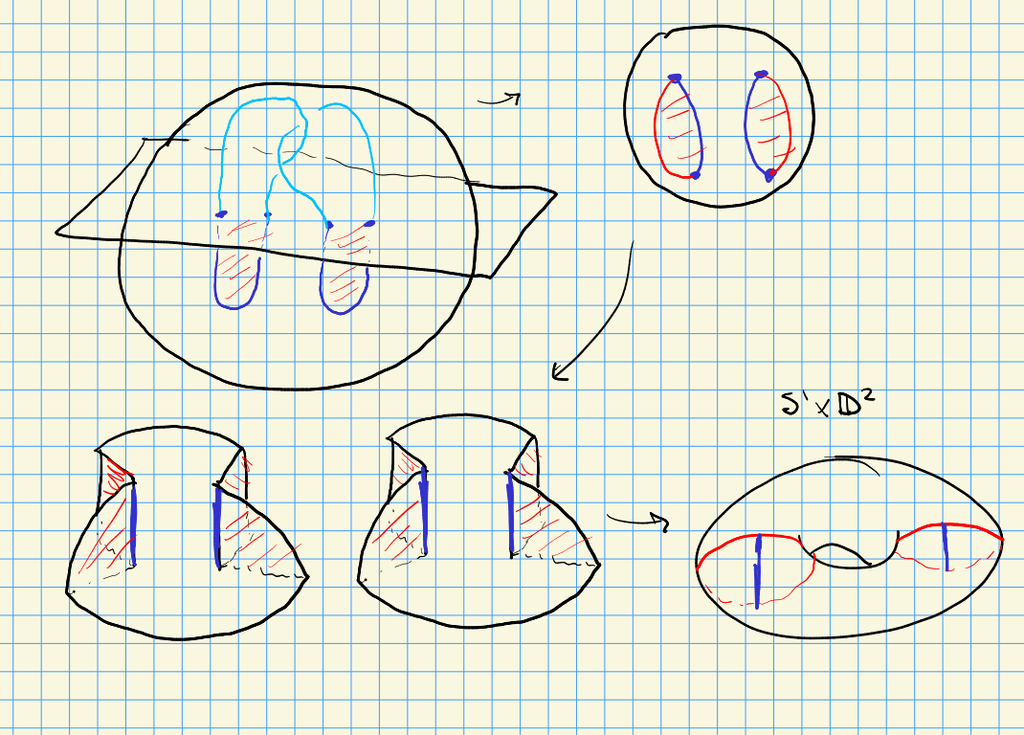

All lens spaces can be generated by genus 1 Heegaard splittings?

$-p/q$ Dehn surgery is equivalent to a sequence of linked unknots with numbers $r_1,\cdots, r_k$. When can this be done in a way that preserves the contact structure? Idea: Legendrian surgery, which removes a Legendrian knot and reglues.

Let $L$ be Legendrian and $\nu(L)$ is a standard neighborhood (so standard contact structure). Then ${{\partial}}\nu(L) \cong T^2$ is convex with 2 dividing curves, where “slope” is the contact framing. For ${\left[ {\theta, x, y} \right]} \in S^1\times {\mathbb{R}}^2$, set $\alpha = \,dx+ y\,d\theta$. Then ${\left[ {\theta, 0, 0} \right]}$ is Legendrian. When can we extend $\xi$ uniquely across surgery $S^1\times {\mathbb{D}}^2$? Need to attach handles along integer framing (choice of integer in $\pi_1 {\operatorname{SO}}_2({\mathbb{R}}) \cong {\mathbb{Z}}$ corresponding to trivializing the normal bundle $\nu (K)$ in an embedding). Need good surgery slopes: $\left\{{n}\right\}_{n\in {\mathbb{Z}}} \cap\left\{{1\over k}\right\}_{k\in {\mathbb{Z}}} = \left\{{\pm 1}\right\}$, relative to the tb-framing. So $\mathrm{tb}-1$ is the best framing.:

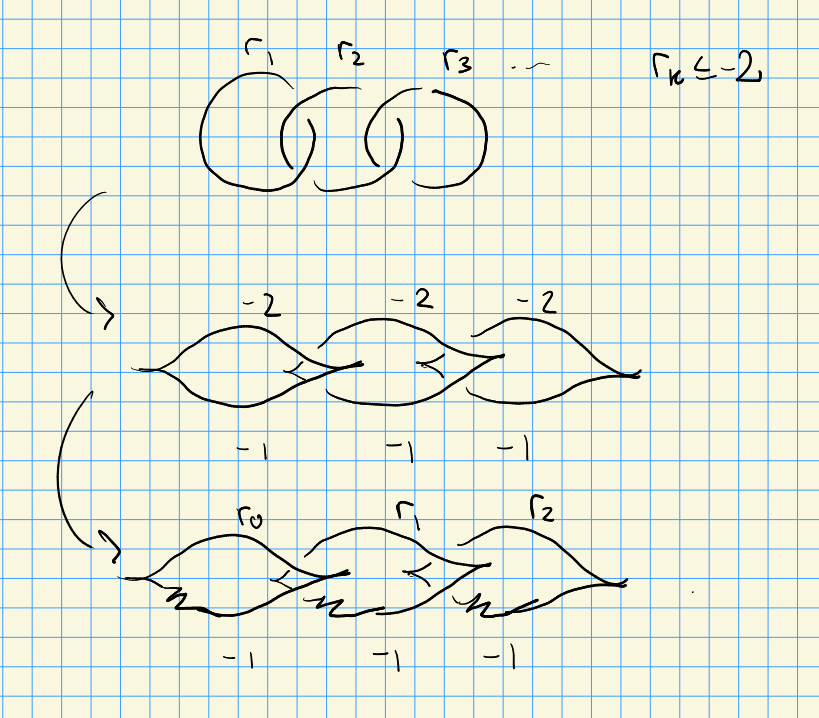

Stabilize up to $r_K+1$ on each Legendrian knot. Fact: yields a Stein fillable thing, implies tight contact structure.

There are $-r_0-1$ ways to perform $-r_0 - 2$ stabilizations. E.g. for $-r_0-2 = 3$, break into positive and negative stabilizations:

- $(3, 0)$
- $(2, 1)$
- $(1, 2)$
- $(0, 3)$

So there are $\prod_{1\leq i\leq k} (-r_k - 1)$ tight contact structures on $-p/q = {\left[ {r_0, \cdots, r_k} \right]}$.

# 16 Tuesday, April 05

## 16.1 Symplectic Fillings

Consider $(S^3, \xi_\text{std}) \subseteq {\mathbb{C}}^2$; some things that are true:

- There is a symplectic form $\omega = dx_1 \wedge dy_1 + dx_2 \wedge dy_2$ where $d\omega = 0$ and $\omega \wedge \omega =2 d\mathrm{Vol} > 0$. Write $\phi = \sum x_i^2 + \sum y_i^2$, then $S^3 = \phi^{-1}(1)$.
- Letting $\rho = \sum x_i {\partial}x_i + \sum y_i {\partial}y_i = {1\over 2}\operatorname{grad}\phi$ in the standard metric yields a contact form $\alpha = \omega(\rho, {-})$.
- Since ${ \left.{{\omega}} \right|_{{\xi_\text{std}}} } > 0$, this yields an area form on contact planes.
- There is also a complex structure $J: {\mathbf{T}}_p {\mathbb{C}}^2 \to {\mathbf{T}}_p {\mathbb{C}}^2$ where $J({\partial}x_i) = {\partial}y_i$ and $J({\partial}y_i) = - {\partial}x_i$ with a compatibility $g(x, y) = \omega(x, Jy)$.

A complex symplectic manifold $(X^4, \omega, J)$ is a filling of $(Y^3, \xi)$ if $Y = {{\partial}}X$,

- **Stein filling**: $(X^4, J)$ is a Stein manifold, and $\xi = {\mathbf{T}}Y \cap J({\mathbf{T}}Y)$.
- **Strong filling**: if there is an outward pointing (Liouville) vector field $\rho$ with ${\mathcal{L}}_\rho \omega = \omega$ with $\xi \ker (\omega(\rho, {-}))$ (which is always contact). Note ${\mathcal{L}}_\rho \omega = d(\iota_\rho \omega) + \iota_\rho(d\omega)$ where the 2nd term vanishes for a symplectic form.
- **Weak filling**: ${ \left.{{\omega}} \right|_{{\xi}} } > 0$.

> Note that we aren’t defining what “Stein” means here.

There are strict implications

- Stein $\implies$
- Strong $\implies$
- Weak $\implies$
- Tight.

Note that the last implication is the harder part of the theorem.

Given $(Y, \xi)$, classify all fillings.

Consider $(T^3, \xi_n)$ – if $n=1$, this is Stein fillable, and for $n\geq 2$ these are weakly fillable but not strongly fillable. In this case, all of the filling manifolds are $T^2 \times {\mathbb{B}}^2$.

For lens spaces $L_{p, q}$ all tight contact structures are Stein fillable with the same smooth filling. Take the linear plumbing $X$ of copies of $S^2$ corresponding to $-p/q = {\left[ {r_1, r_2, \cdots, r_k} \right]}$ as a continued fraction expansion. They’re distinguished by Chern classes $c_1(T_X, J)$.

Brieskorn spheres are examples of fillings, related to Milnor fibers. For $p,q,r \geq 2$, define
$$\begin{align*}
\Sigma(p,q,r) \mathrel{\vcenter{:}}=\left\{{F_{p,q,r}(x,y,z) = x^p + y^q + z^r = {\varepsilon}}\right\} \cap S^5 \subseteq {\mathbb{C}}^3 = \mathop{\mathrm{span}}_{\mathbb{C}}\left\{{x,y,z}\right\}
.\end{align*}$$

In this case, we have:

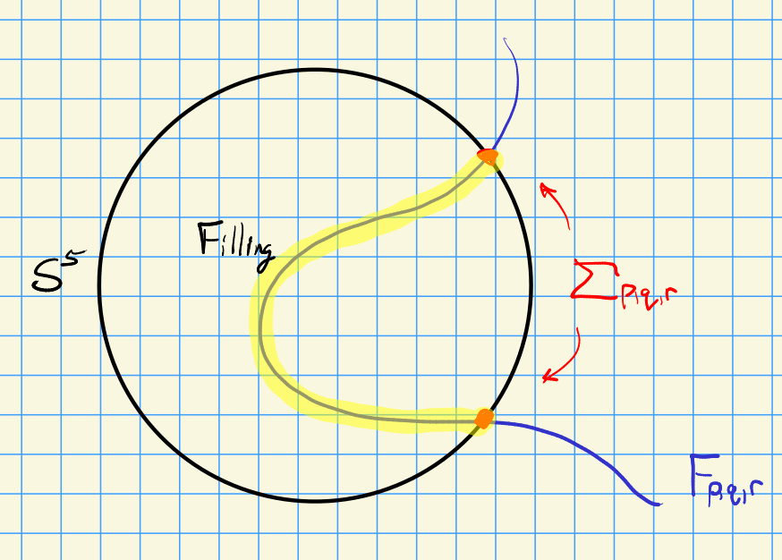

Note that ${\varepsilon}= 0$ yields a singular variety, while ${\varepsilon}>0$ small yields a smooth manifold.

Show $\Sigma_{p,q,r}$ is the $r{\hbox{-}}$fold cyclic branched cover of $S^3$ over the torus knot $T_{p, q}$.

Let $J: {\mathbf{T}}X\to {\mathbf{T}}X$ with $J^2 = -\operatorname{id}$, so the eigenvalues are $\pm i$. So consider complexifying to ${\mathbf{T}}_{\mathbb{C}}X \mathrel{\vcenter{:}}={\mathbf{T}}X \otimes_{\mathbb{R}}{\mathbb{C}}$, so e.g. ${\partial}x_k \mapsto (a_k + i b_k) {\partial}x_k$. This splits into positive (holomorphic) and negative (antiholomorphic) eigenspaces ${\mathbf{T}}^{1, 0}_{\mathbb{C}}X \oplus {\mathbf{T}}^{0, 1}_{\mathbb{C}}X$. Take a change of basis ${\left[ {x_1, y_1, x_2, y_2} \right]} \mapsto {\left[ {z_1, \mkern 1.5mu\overline{\mkern-1.5muz\mkern-1.5mu}\mkern 1.5mu_1, z_2, \mkern 1.5mu\overline{\mkern-1.5muz\mkern-1.5mu}\mkern 1.5mu_2} \right]}$ which yields ${\partial}z = {1\over 2}\qty{{\partial}x - i {\partial}y}$ and ${ \mkern 1.5mu\overline{\mkern-1.5mu{\partial}\mkern-1.5mu}\mkern 1.5mu}z = {1\over 2}\qty{{\partial}x + i {\partial}y}$.

Let $f(z) = {\left\lvert {z} \right\rvert}^2$ and check

- ${\partial}{ \mkern 1.5mu\overline{\mkern-1.5mu{\partial}\mkern-1.5mu}\mkern 1.5mu}f = {\partial}(z d\mkern 1.5mu\overline{\mkern-1.5muz\mkern-1.5mu}\mkern 1.5mu) = dz \wedge d\mkern 1.5mu\overline{\mkern-1.5muz\mkern-1.5mu}\mkern 1.5mu = -2i (dx \wedge dy)$.
- $d = {\partial}+ { \mkern 1.5mu\overline{\mkern-1.5mu{\partial}\mkern-1.5mu}\mkern 1.5mu}$

Practicing this type of change of variables is important!

Let $\phi: X\to {\mathbb{R}}$ for $X$ a complex manifold, then the **Levi form** of $\phi$ is
$$\begin{align*}
{\mathcal{L}}\phi = {\partial}{ \mkern 1.5mu\overline{\mkern-1.5mu{\partial}\mkern-1.5mu}\mkern 1.5mu}\phi = \sum_{i, j} {{\partial}^2 \over {\partial}z_j { \mkern 1.5mu\overline{\mkern-1.5mu{\partial}\mkern-1.5mu}\mkern 1.5mu}\mkern 1.5mu\overline{\mkern-1.5muz\mkern-1.5mu}\mkern 1.5mu_k} dz_j \wedge d\mkern 1.5mu\overline{\mkern-1.5muz\mkern-1.5mu}\mkern 1.5mu_k
,\end{align*}
generalizing the Hessian. The function \(\phi\) is plurisubharmonic if \({\mathcal{L}}\phi\) is positive semidefinite at every point.$$

Consider $\phi: {\mathbb{C}}\to {\mathbb{R}}$, then
$$\begin{align*}
{\mathcal{L}}\phi
&= {\partial}{ \mkern 1.5mu\overline{\mkern-1.5mu{\partial}\mkern-1.5mu}\mkern 1.5mu}\phi \\
&= 2\qty{{1\over 2}\qty{\phi_x + i\phi_y}}\\
&= {1\over 2}\qty{ {1\over 2}\qty{\phi_{xx} - \phi_{xy}} + {1\over 2}\qty{ \phi_{yx} - i \phi_{yy}}} \\
&= {1\over 4}\qty{\phi_{xx} + \phi_{yy}}\\
&= {1\over 4}\Delta\phi
,\end{align*}
so plurisubharmonic implies positive Laplacian. Note that in 1 dimension, \(\Delta f = 0 \implies f'' = 0\), so \((x, f(x))\) is a straight line. In higher dimensions, \(f''>0\) forces convexity, so secant lines are under the straight lines, hence the “sub” in subharmonic.$$

If $\phi: X\to {\mathbb{R}}$ is plurisubharmonic and $0$ is a regular value, then $(\phi^{-1}(0), \xi)$ (where $\xi$ is its complex tangencies) forms a contact structure and the sub-level set $\phi^{-1}(-\infty, 0]$ is a Stein filling.

The radical function $\phi: {\mathbb{C}}^3\to {\mathbb{R}}$ where $\phi(z_1,z_2,z_3) = \sum {\left\lvert {z_i} \right\rvert}^2$ is plurisubharmonic, as is its restriction to any submanifold of ${\mathbb{C}}^3$, including any filling of $\Sigma_{p,q,r}$. Hard theorem: any Stein manifold and any Stein filling essentially comes from this construction.

# 17 Thursday, April 21

> Note: student talks in previous weeks!

Possible topics for the remainder of the class:

- Open book decompositions
- Every $(Y^3, \xi)$ is homotopic to a contact structure.
- Seifert fibered spaces

## 17.1 Seifert Fibered Spaces

Brieskorn spheres $\Sigma(p,r,q) \mathrel{\vcenter{:}}=\left\{{x^p + y^q + z^r = 0}\right\} \cap S_{\varepsilon}^5 \subseteq {\mathbb{C}}^3$ are 3-manifolds *foliated* by $S^1$. Note that $S_1\to X \to S^2$ for $X = S^3$ or $L(p, q)$ are actual fibrations. Idea: a foliation by $F$’s is a decomposition $X = {\textstyle\coprod}F \to B$ which is a fibration with ramification in some fibers.

A **Seifert fibered space** associated to $(\Sigma, (p_1/q_1, \cdots, p_n/q_n))$ with $p_i/q_i\in {\mathbb{Q}}$ and $\Sigma$ an orbifold surface is a 3-manifold $Y$ and knots $L_1,\cdots, L_n$ with neighborhoods $\nu L_i$ such that

- $Y\setminus\cup_i\nu(L_i) = (\Sigma\setminus\left\{{{\operatorname{pt}}_1,\cdots, {\operatorname{pt}}_n}\right\}) \times S^1$
- $\nu L_i = S^1\times {\mathbb{D}}^2$ is glued in by $p_i/q_i$ Dehn surgery.

$L(p, q)$ is $-p/q$ surgery on $S^1$, or by a slam-dunk move:

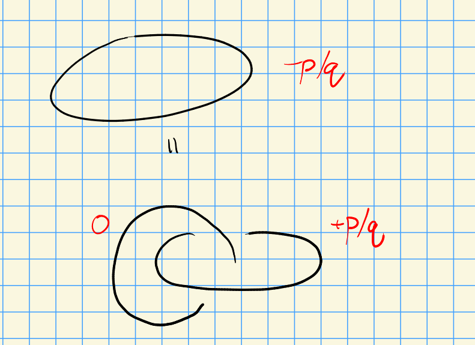

$\Sigma(p,q,r)$:

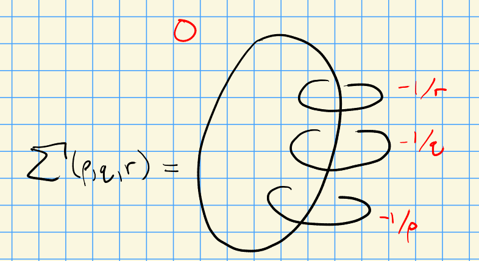

Show that for $\Sigma(p,q,r)$, removing the axes in ${\mathbb{C}}^3$ yields a trivial fibration by copies of $S^1$ over $S^2\setminus{{\operatorname{pt}}_1,{\operatorname{pt}}_2,{\operatorname{pt}}_3}$ and check the surgery slopes.

Prove that $\Sigma(p,q,r)$ comes from the plumbing diagram for the Milnor fibration using Kirby calculus.

# 18 Tuesday, April 26

Recall that $\operatorname{PHS}^3 = \Sigma(2,3,5)$ has a Stein-fillable (and hence tight) contact structure.

The negative $-\Sigma(2,3,5)$ admits no tight contact structures.

Let $S=S^3\setminus\left\{{ {\operatorname{pt}}_1,{\operatorname{pt}}_2,{\operatorname{pt}}_3 }\right\}$ be a pair of pants and consider $X = S\times S^1$. Note ${{\partial}}X = T^2\cup T^2\cup T^2$:

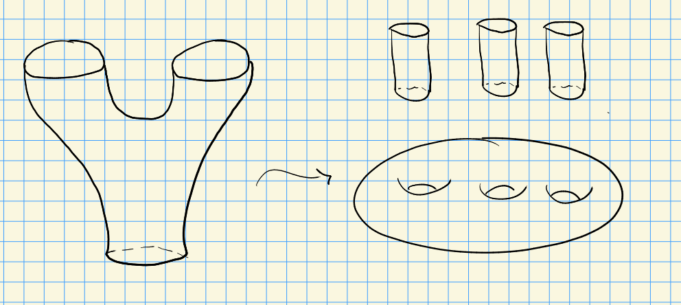

Note $-\Sigma(2,3,5) = \Sigma(2,-3,-5)$, since $\operatorname{PHS}^3$ is $-1$ surgery on the trefoil. Glue in 3 solid torii by
$$\begin{align*}
A_1 = {
\begin{bmatrix}
{2} & {-1}
\\
{1} & {0}
\end{bmatrix}
}, \quad A_2 = {
\begin{bmatrix}
{3} & {1}
\\
{-1} & {0}
\end{bmatrix}
}, \quad A_3 = {
\begin{bmatrix}
{5} & {1}
\\
{-1} & {0}
\end{bmatrix}
}
.\end{align*}
acting on \({\left[ {m, \lambda} \right]}\) in \(S^1\times {\mathbb{D}}^2\):$$

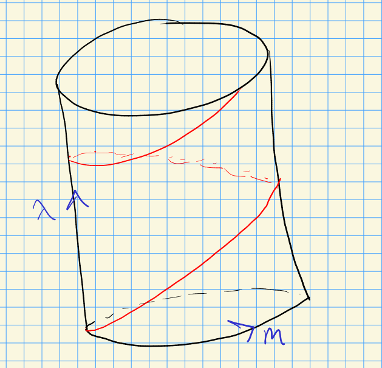

Show via Kirby calculus:

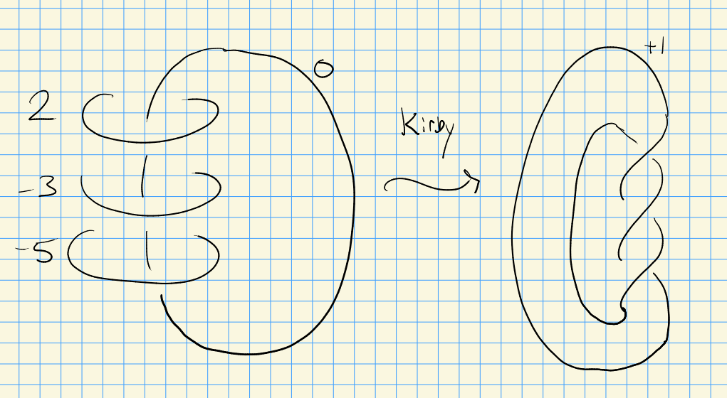

There exist Legendrian representatives $F_2, F_3$ with twisting numbers $m_2, m_3 = -1$.

Idea: by stabilization, we can assume $m_2,m_3 < 0$, and the claim is that we can destabilize them back up to $-1$ simultaneously using bypass moves. Reduce to studying dividing sets on $T^2\times I$ or $S^1\times {\mathbb{D}}^2$. Check that the dividing set has slope $-1/2$, which implies that there is an overtwisted disc. Reduce to $2\cdot 3\cdot 5 = 30$ cases, check that an overtwisted disc can be found in each case.

# 19 Bibliography